# EWAS

- Show All Code
- Hide All Code
- View Source

We now have everything an epigenome-wide association study needs: a normalized, filtered methylation matrix (chapter 02–chapter 03), cell-composition estimates (chapter 04), and surrogate variables that absorb technical structure (chapter 05). This notebook fits the association model, checks that it is well-calibrated, and provides guidance for interpreting results. It also lays out **two modeling conventions** you will meet in the literature — methylation-as-outcome vs. phenotype-as-outcome — and a residualization workflow that is common in practice.

The worked example tests **PTSD case/control status** against methylation at each CpG, adjusting for sex, age, cell composition, genetic ancestry, and surrogate variables.

**NoteWhat this chapter needs**

This chapter starts from `data/05_mvals_combat.rds`, written by chapter 05. If you did not run that chapter, fetch the published checkpoint instead:

```
Terminal
```

```bash
./get_data.sh E_model_inputs
```

```r
library(limma)   # lmFit(), eBayes(), topTable()
library(bacon)   # bacon(), and the four diagnostic plots in section 4
library(dplyr)   # select(), mutate(), joins and grouped summaries on result tables

# The matrix the model is fit to: the stratified-ComBat M-values chapter 05
# wrote, 756,251 probes x 86 samples. It is ~510 MB on disk and about the same
# again in memory, so this read takes several seconds.
Mcb <- readRDS("data/05_mvals_combat.rds")

# Its small companion, which is committed to the repository: the 86-sample
# phenotype table (which carries the genetic ancestry PCs pc1-pc3), the six cell
# proportions from chapter 04, the smoking proxy, and the surrogate variables
# with the k that chapter 05's sweep settled on.
sv_pieces <- readRDS("data/05_sva.rds")
mdk   <- sv_pieces$mdk            # phenotype table (incl. pc1-pc3), rows in Mcb's column order
propk <- sv_pieces$propk          # CD8T, CD4T, NK, Bcell, Mono, Neu
smoke <- sv_pieces$smoke          # continuous smoking proxy score
K     <- sv_pieces$k_selected     # the k chapter 05 settled on
SV    <- sv_pieces$SV[, seq_len(K)]

# lmFit() pairs matrix columns with design rows by position and does not check
# that they describe the same samples, so confirm the counts agree here.
stopifnot(ncol(Mcb) == nrow(mdk))

# Control is the reference level, which is what makes the tested coefficient
# `ptsdCase` and makes its sign read as case minus control rather than the
# reverse. Left to alphabetical ordering, "Case" would become the reference.
ptsd    <- relevel(factor(mdk$ptsd), ref = "Control")
is_case <- ptsd == "Case"

# `ew` is the handoff object this chapter saves as data/06_ewas.rds and that
# chapter 08 reads back. The sample counts are known before any model is fit;
# the design size, the results table and lambda are added below as they are
# computed, and the whole list is written out in one place at the end.
ew <- list(n = ncol(Mcb), ncase = sum(is_case), nctrl = sum(!is_case),
           k_sv = K, n_tested = nrow(Mcb),
           panel_excluded = sv_pieces$excluded_n)

cat("EWAS matrix:", nrow(Mcb), "probes x", ncol(Mcb), "samples | k =", K, "\n")
```

```
EWAS matrix: 756251 probes x 86 samples | k = 6
```

## 1. Two ways to write the model — and why the outcome matters

There are two ways to set up the per-CpG regression, and they answer subtly different questions.

**(a) Methylation as the outcome**:

$$\text{methylation}_{\text{CpG}} \sim \text{PTSD} + \text{sex} + \text{age} + \text{cell composition} (+ \text{SVs})$$

**(b) Phenotype as the outcome**:

$$\text{PTSD} \sim \text{methylation}_{\text{CpG}} + \text{sex} + \text{age} + \text{cell composition} (+ \text{SVs})$$

Both are used, but **methylation-as-outcome** is the field standard for EWAS for several reasons:

- **Methylation is the measured, continuous response.** Treating the β/M-value as the dependent variable matches the data-generating process: you measured methylation and ask what it varies with.
- **It generalizes to any exposure type.** With methylation as outcome, the predictor of interest can be binary (PTSD), continuous (BMI, age, pack-years), or ordinal — the model form doesn’t change. Phenotype-as-outcome forces a different link function for each exposure type (logistic for binary, linear for continuous), complicating a genome-wide pipeline.
- **Effect sizes are biologically legible.** A coefficient in the methylation-outcome model is “change in methylation per unit exposure” — a Δβ you can read as a percent methylation difference.
- **It is what meta-analysis tools expect.** METAL and comparable tools combine per-CpG **effect sizes and standard errors** on a common scale; the methylation-outcome β/SE is that common currency across cohorts.

When would you flip it to phenotype-as-outcome? Mainly when methylation is conceived as a **predictor/biomarker** of the phenotype — e.g. building a methylation risk score, or asking “does methylation at this locus predict disease?” rather than “does disease associate with methylation here?”.

**NoteTest on M-values, report on β-values**

Regardless of the outcome convention, the statistical test is run on **M-values** (logit-transformed β), which are approximately homoscedastic and better satisfy the model’s variance assumptions (Du et al. 2010). Effect sizes are then reported as **Δβ** because a β difference is biologically interpretable — a Δβ of 0.05 is a “5% methylation change.”

## 2. The covariate set

Our design includes covariates for everything we established as a driver of methylation:

- **sex** and **age** — strong, ubiquitous methylation covariates (chapter 05 confirmed both drive leading PCs).
- **cell composition** (6 estimated proportions) the single largest source of variance in whole blood (chapter 04).
- **a smoking proxy** — this cohort has no recorded smoking variable, so chapter 05 builds one from a published panel of replicated smoking-associated CpGs. The panel probes themselves are excluded from testing.
- **genetic ancestry** — the three genetic ancestry PCs (`pc1`–`pc3`) deposited with the series, introduced in chapter 05.
- **array position** — the chip row (`R01C01`…`R08C01`), a recorded technical factor that is estimable here and so enters as a fixed effect (7 dummy columns).
- **surrogate variables** — the 6 SVs retained in chapter 05, which absorb structure that none of the measured covariates name.

Chapters 01–04 worked with all **96** QC-passing arrays, because none of those steps needs the exposure. The batch correction and surrogate variables in chapter 05 do, so that chapter already set aside the nine samples with no recorded PTSD status and the one sample with no genetic ancestry PCs. The matrix loaded above is therefore the same modeled set, and the EWAS fits **n = 86** (31 cases, 55 controls). No sample was excluded for quality — see phenotype completeness.

**NoteSmoking**

Smoking is well established to cause distinct, systemic methylation changes, so it is important to include as a covariate in modeling if you have that information available. If you don’t, there are methods to predict smoking status from a subset of methylation sites (these sites would then be excluded from the EWAS). Alternatively, you can exclude CpGs identified as strongly associated with smoking from previous literature prior to or post EWAS (prior is recommended if using this option). Lastly, surrogate variables can capture latent variation due to smoking if you don’t have a smoking variable included in the null model, but use this option with caution as the surrogate variables may attenuate more biological signal than intended. As a last resort, you can run the EWAS without accounting for smoking, just keep this in mind while interpreting results.

**NotePicking the chapter up from the saved fit instead**

Fitting 756,251 probes needs the 510 MB ComBat matrix in memory with a few GB of working space on top of it. If that is not practical on your machine, fetch the published fit and read it instead of running the chunks that fit and save the model: `ewas-fit` below, and `run-bacon`, `bacon-summary`, `bacon-diagnostics` and `save-ewas` in section 4 and at the end of the chapter:

```
Terminal
```

```bash
./get_data.sh F_ewas_results
```

```
RStudio Console
```

```r
ew <- readRDS("data/06_ewas.rds")
tt <- ew$tt                                   # already carries the BACON columns
bs <- readRDS("data/06_bacon_summary.rds")
```

Every other number, table and figure in this chapter will then run. The four BACON diagnostic plots are the one thing you lose, because they are drawn from the `bc` object rather than from the saved table.

```r
# Array position is an 8-level factor on an EPIC chip, so it costs 7 dummy
# columns. Rebuilding the factor from as.character() drops any level the sample
# sheet defines but no modeled sample occupies; an empty level would add an
# all-zero dummy column and leave the design rank-deficient.
pos <- factor(as.character(mdk$array_pos))

# Every model term goes into one data frame so that model.matrix() can name the
# columns it builds: `propk` expands to the six cell proportions by their own
# names, and `SV` to SV1...SV6. check.names = FALSE keeps those names intact.
# pc1-pc3 are the genetic ancestry PCs carried on mdk from chapter 05.
dd <- data.frame(ptsd = ptsd, sex = factor(mdk$sex), age = mdk$age,
                 smoke = smoke, pos = pos,
                 pc1 = mdk$pc1, pc2 = mdk$pc2, pc3 = mdk$pc3,
                 propk, SV = SV, check.names = FALSE)
design <- model.matrix(~ ptsd + sex + age + smoke + pos + pc1 + pc2 + pc3 +
                         CD8T + CD4T + NK + Bcell + Mono + Neu + SV, data = dd)
stopifnot("ptsdCase" %in% colnames(design))
ew$design_ncol <- ncol(design)
ew$resid_df    <- ncol(Mcb) - ncol(design)

# 756,251 least-squares fits in a single call -- which is why limma is the tool
# here rather than a loop over lm(). This is the expensive step in the chapter:
# roughly a minute, and several GB while the per-probe coefficients and residual
# variances are held in memory.
fit <- lmFit(Mcb, design)        # per-probe weighted least squares
fit <- eBayes(fit)               # empirical-Bayes moderation of the variance

# sort.by = "P" fixes the row order of the saved table to increasing p-value;
# topTable()'s default sorts by the log-odds column B instead.
#
# limma:: is required, not decoration. bacon exports its own topTable method,
# and because bacon is attached after limma above, a bare topTable() call
# resolves to bacon's -- whose signature is (object, number, adjust.method,
# sort.by) and which fails with "unused argument (coef = ...)". Qualifying the
# call is the fix that does not depend on library() order.
tt <- limma::topTable(fit, coef = "ptsdCase", number = Inf, sort.by = "P")
tt$probe <- rownames(tt)

# Delta-beta: the case-minus-control difference on the beta scale, taken from
# the same ComBat-adjusted M-values the model saw, so the effect reported and
# the effect tested describe one matrix. The back-transform is a second copy of
# 756,251 x 86 doubles, so it is dropped again as soon as the means are taken.
bcb <- 2^Mcb / (2^Mcb + 1)
db  <- rowMeans(bcb[, is_case],  na.rm = TRUE) -
       rowMeans(bcb[, !is_case], na.rm = TRUE)
tt$delta_beta <- db[tt$probe]
rm(bcb); invisible(gc())

# Genomic inflation factor from the p-values: the conventional definition, and
# the same one chapter 05's k-selection sweep used, so the two are comparable.
lam    <- function(p) median(qchisq(1 - p, 1), na.rm = TRUE) / qchisq(0.5, 1)
lambda <- lam(tt$P.Value)

# Fix the column order of the table that gets saved and deposited.
tt <- select(tt, probe, logFC, delta_beta, AveExpr, t, P.Value, adj.P.Val, B)
```

`limma`’s `eBayes` step is what makes this appropriate for an EWAS on a modest sample size: it moderates each probe’s variance toward a pooled estimate, stabilizing the t-statistics for the ~700k probes tested (Ritchie et al. 2015).

```r
cat(sprintf("EWAS sample size: n = %d  (%d cases, %d controls)\n", ew$n, ew$ncase, ew$nctrl))
```

```
EWAS sample size: n = 86  (31 cases, 55 controls)
```

```r
cat(sprintf("Design columns (covariates + intercept): %d\n", ew$design_ncol))
```

```
Design columns (covariates + intercept): 27
```

```r
cat(sprintf("Residual degrees of freedom per probe:   %d\n", ew$resid_df))
```

```
Residual degrees of freedom per probe:   59
```

```r
cat(sprintf("Surrogate variables retained:            %d\n", ew$k_sv))
```

```
Surrogate variables retained:            6
```

```r
cat(sprintf("CpGs tested: %s  (%d smoking-panel probes excluded)\n",
            format(ew$n_tested, big.mark = ","), ew$panel_excluded))
```

```
CpGs tested: 756,251  (20 smoking-panel probes excluded)
```

## 3. Is the model well-calibrated? The QQ plot and genomic inflation

Before looking at *which* CpGs are top-ranked, check whether the p-values behave. The **genomic inflation factor** λ compares the median observed test statistic to its null expectation. λ ≈ 1 means the model is well-calibrated; λ ≫ 1 signals residual confounding (unmodeled batch, cell composition, or population structure) inflating the statistics; λ ≪ 1 can signal over-correction, but may also indicate that there truly is very little differential methylation or the sample size is underpowered to detect true signals. Due to the biological differences between genetic variants and methylation and the technical design differences in how they are measured in arrays, EWAS results tend to have inflated λ compared to GWAS results. Additional bias and inflation correction is performed post-EWAS to account for this. The lambda post-bias-and-inflation correction is what should be used to judge the model fit.

## 4. Correcting residual bias and inflation with BACON

**BACON** (Iterson et al. 2017) estimates the *empirical null distribution* of the test statistics with a Bayesian three-component mixture (one null component plus two alternative components for positive and negative effects), then rescales every statistic to that estimated null. This corrects both **bias** (a non-zero center of the null — a systematic shift) and **inflation** (a null wider than N(0,1) — the same phenomenon λ measures), and it does so without assuming that all deviation from the diagonal is confounding.

Always run BACON on your EWAS results:

- A λ near 1 does not mean there is *no* residual bias — bias (a shift of the null’s center) barely moves λ, which is driven by the *spread* of the statistics. BACON estimates and removes both.
- Applying the empirical-null correction and *inspecting its diagnostics* is what lets you distinguish “well-calibrated” from “looks calibrated by one number.”

BACON works from either t-statistics *or* effect sizes and their standard errors. We chose effect sizes and standard errors as we can derive these from the output of limma and these estimates are needed down stream if a meta-analysis is performed.

```r
# The Gibbs sampler is stochastic, so the seed is what makes the inflation,
# the bias and every adjusted p-value below reproducible run to run.
set.seed(42)

es <- tt$logFC              # effect size per CpG
se <- tt$logFC / tt$t       # standard error = beta / t-statistic

# 5,000 iterations with 2,000 burn-in (bacon's defaults) over all 756,251
# statistics: about a minute. bacon estimates inflation and bias from the test
# statistics; the effect sizes and standard errors are passed as well so that
# es() and se() below can return their corrected versions. limma's t equals
# es / se here, so all three describe the same statistic.
bc <- bacon(teststatistics = tt$t, effectsizes = es, standarderrors = se)

# es() and se() below are bacon's accessor functions, not the two numeric
# vectors of the same name defined above: R resolves a name used in function
# position to a function and skips the vector.
inflation(bc)   # estimated inflation (sigma.0); 1 = none
```

```
 sigma.0
1.007026
```

```r
bias(bc)        # estimated bias (mu); 0 = none
```

```
      mu.0
0.01583547
```

```r
# pval(), es() and se() each return a one-column matrix; [, 1] takes that column
# as a plain numeric vector, so the table's columns are ordinary numbers.
tt$bacon.p  <- pval(bc)[, 1]     # empirical-null-adjusted p-values
tt$bacon.es <- es(bc)[, 1]       # adjusted effect sizes
tt$bacon.se <- se(bc)[, 1]       # adjusted standard errors

# BH across the adjusted p-values. The results section thresholds on this
# column, so it has to be computed from bacon.p rather than reused from limma.
tt$bacon.adj.P <- p.adjust(tt$bacon.p, method = "BH")
```

```r
# The four calibration numbers, collected into the object saved at the end of
# the chapter as data/06_bacon_summary.rds. lambda_raw is limma's, lambda_bacon
# is the same statistic recomputed on the empirical-null-adjusted p-values.
bs <- list(inflation    = inflation(bc),
           bias         = bias(bc),
           lambda_raw   = lambda,
           lambda_bacon = lam(tt$bacon.p),
           n            = ew$n)
cat(sprintf("Estimated inflation (sigma.0): %.3f\n", bs$inflation))
```

```
Estimated inflation (sigma.0): 1.007
```

```r
cat(sprintf("Estimated bias (mu):           %.3f\n", bs$bias))
```

```
Estimated bias (mu):           0.016
```

```r
cat(sprintf("lambda before BACON:           %.3f\n", bs$lambda_raw))
```

```
lambda before BACON:           1.025
```

```r
cat(sprintf("lambda after  BACON:           %.3f\n", bs$lambda_bacon))
```

```
lambda after  BACON:           1.022
```

Here the model was already well-calibrated (λ ≈ 1.03), so BACON changes little — the estimated inflation is ≈ 1 and the adjusted λ stays close to 1. That is the *reassuring* outcome: the correction is available and applied, and it confirms rather than rescues the analysis. On a poorly-specified model you would instead see inflation ≫ 1 pulled back toward 1, and the diagnostics below would show it.

### Always inspect the four BACON diagnostic plots

The single number can hide a mis-specified or non-converged fit. BACON’s Gibbs sampler produces four diagnostic plots, and you should look at all four every time. (The interpretation below follows the guidance in the [pipeline repository](https://github.com/krferrier/EWAS) README, where these are documented in full.)

```r
# The four plots below are drawn from `bc` and written to disk here, so the
# figures that follow display this run rather than a stored copy of an older
# one. They are base and lattice graphics rather than ggplots, so each goes to
# its own jpeg() device instead of through ggsave().
dir.create("data/06_bacon", showWarnings = FALSE, recursive = TRUE)

# fit() is bacon's mixture-fit plot. The limma object named `fit` above does not
# get in the way, for the same reason es() and se() still worked: a name in
# function position resolves to a function.
jpeg("data/06_bacon/fit.jpg", width = 1600, height = 1200, res = 200)
print(fit(bc, n = 100))                  # n = 100 histogram bins
```

```r
dev.off()
```

```r
jpeg("data/06_bacon/qq.jpg", width = 1600, height = 1200, res = 200)
print(plot(bc, type = "qq"))             # a ggplot, hence the print()
dev.off()
```

```r
# traces() and posteriors() draw straight onto the device, so no print() here.
# burnin = FALSE shows the chain after burn-in only, which is the part you
# judge convergence on.
jpeg("data/06_bacon/traces.jpg", width = 1600, height = 1400, res = 180)
traces(bc, burnin = FALSE)
dev.off()
```

```r
jpeg("data/06_bacon/posteriors.jpg", width = 1600, height = 1200, res = 200)
posteriors(bc)
dev.off()
```

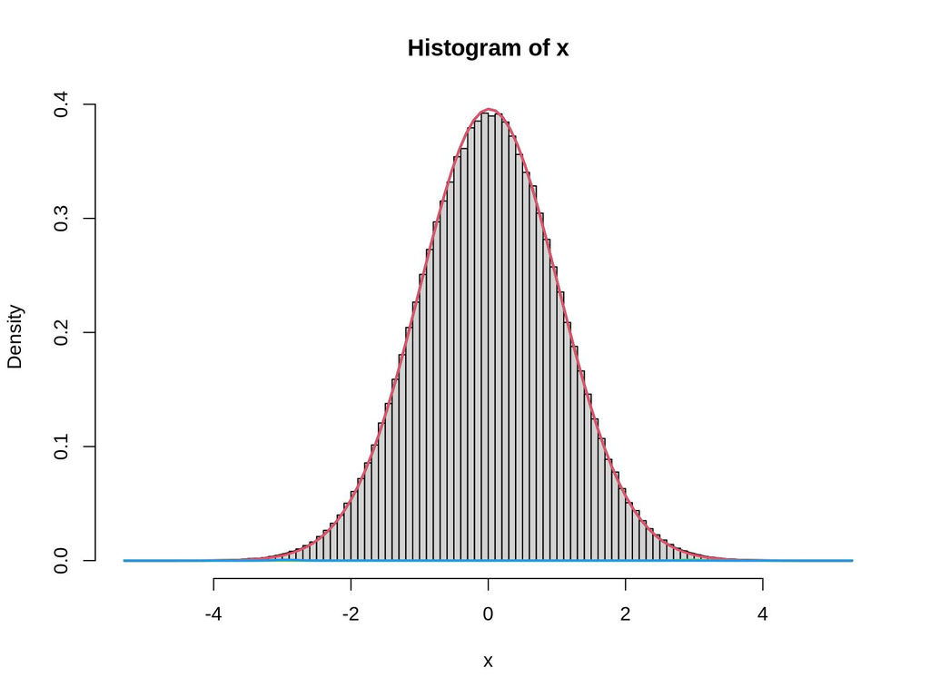

**Fit plot.** Histogram of the observed z-scores with the fitted three-component mixture overlaid: the black curve is the overall fit, red is the estimated null component, and blue/green are the two alternative components. The black curve tracks the histogram closely — the model is well-specified. A large gap between the fitted (black) and observed (histogram) densities would signal mis-specification or non-convergence.

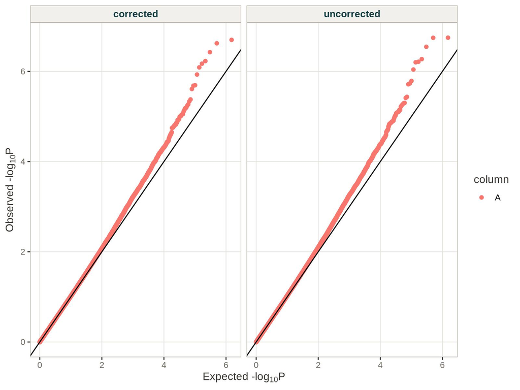

**QQ plots, before (uncorrected) and after (corrected) BACON.** Points should hug the diagonal, breaking upward into a tail spike only for genuine associations. Systematic departure from the line *before* the spike is bias/inflation; after correction the bulk of points should sit closer to the diagonal. Here the two panels are nearly identical because the input was already calibrated.

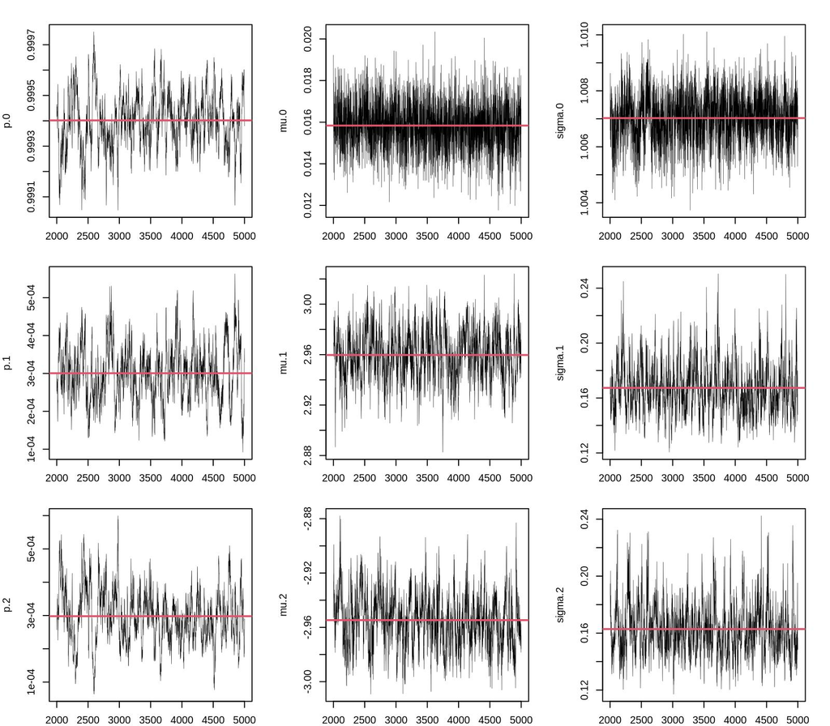

**Traces plot.** The Gibbs sampler’s value for each parameter (p, mu, sigma for each of the three components) across iterations. A well-mixed, converged chain looks like a fuzzy horizontal band with a narrow range in estimates — a ‘hairy caterpillar’ — with no drift or trend. A sharp early sweep followed by settling is normal (the prior was far from the estimate); a chain that never settles means non-convergence.

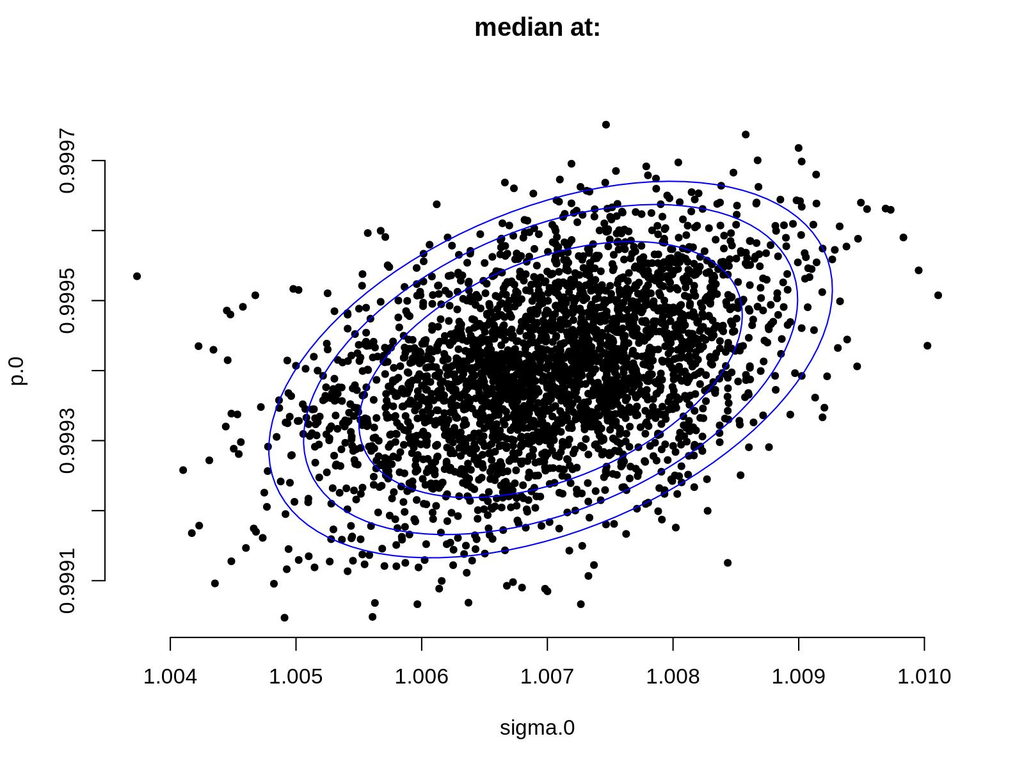

**Posteriors plot.** Scatter of the sampled posterior draws for the null inflation (sigma.0) and the null proportion (p.0), with 75/90/95% probability ellipses. A dense, roughly elliptical cloud sitting inside the contours indicates the sampler converged on a stable estimate; a sparse or lopsided cloud spilling outside the ellipses indicates it did not.

In this run the fit tracks the histogram, the QQ panels are near-diagonal, the traces are hairy caterpillars, and the posteriors form a dense cloud inside the ellipses — all four say the sampler converged and the empirical null is trustworthy.

**ImportantMake BACON a default, and read the diagnostics**

Report BACON-adjusted effect sizes and p-values as your primary EWAS results. It is not usually necessary to report the diagnostic plots, but I strongly recommend reporting the adjusted lambda.

And it is not a substitute for a better model: if your λ is inflated because of unmodeled batch or cell composition, the right response is to fix that (chapters 04 and 05) rather than lean on BACON. Use it for the residual bias that remains after adjustment.

## 5. Results

```r
bonf   <- 0.05 / nrow(tt)
n_bonf <- sum(tt$bacon.p < bonf)
n_fdr  <- sum(tt$bacon.adj.P < 0.05)
cat(sprintf("Probes tested: %s\n", format(nrow(tt), big.mark = ",")))
```

```
Probes tested: 756,251
```

```r
cat(sprintf("Bonferroni-significant (p < %.2g): %d\n", bonf, n_bonf))
```

```
Bonferroni-significant (p < 6.6e-08): 0
```

```r
cat(sprintf("FDR < 0.05: %d\n", n_fdr))
```

```
FDR < 0.05: 0
```

```r
top6 <- tt %>%
  arrange(bacon.p) %>%
  select(probe, logFC, delta_beta, P.Value, bacon.p, bacon.adj.P) %>%
  head(6)
knitr::kable(top6,
             digits = c(0, 3, 4, 8, 8, 4), row.names = FALSE,
             col.names = c("probe", "logFC", "delta_beta", "P (limma)",
                           "P (BACON)", "FDR (BACON)"),
             caption = "Top 6 CpGs, ranked by BACON-adjusted p-value. logFC is the M-value effect; delta_beta is the case−control β difference (interpretable as percent methylation).")
```

Top 6 CpGs, ranked by BACON-adjusted p-value. logFC is the M-value effect; delta_beta is the case−control β difference (interpretable as percent methylation).

| probe | logFC | delta_beta | P (limma) | P (BACON) | FDR (BACON) |
| --- | --- | --- | --- | --- | --- |
| cg15434749 | -0.385 | -0.0259 | 2.15e-06 | 2.0e-07 | 0.0901 |
| cg20600436 | 0.171 | 0.0141 | 2.16e-06 | 2.4e-07 | 0.0901 |
| cg25717994 | 0.310 | 0.0059 | 2.98e-06 | 3.7e-07 | 0.0944 |
| cg02045051 | -0.180 | -0.0071 | 4.65e-06 | 5.9e-07 | 0.1021 |
| cg18321729 | -0.215 | -0.0053 | 5.12e-06 | 6.8e-07 | 0.1021 |
| cg26807989 | 0.317 | 0.0268 | 5.22e-06 | 8.1e-07 | 0.1027 |

0 CpGs pass Bonferroni and 0 pass FDR < 0.05 — a null result that a study of this size cannot settle either way. A null result is not unusual at this sample size. The Grady Trauma Project was one of 23 cohorts in the Psychiatric Genomics Consortium PTSD meta-analysis of blood DNA methylation, which with 5,077 participants (2,156 PTSD cases and 2,921 trauma-exposed controls) identified 11 CpGs associated with PTSD (Katrinli et al. 2024).

The next code blocks produce a Manhattan plot, a QQ plot and a volcano plot from the BACON-adjusted results. No CpG reaches epigenome-wide significance: the strongest, `cg15434749`, has a BACON-adjusted p = 2.00 × 10⁻⁷ against a Bonferroni threshold of 6.61 × 10⁻⁸, and an FDR of 0.090.

A Manhattan plot needs a genomic position for every CpG. Here they come from Zhou’s hg38 coordinates, the same annotation chapter 08 uses:

```r
library(data.table)   # fread() for the coordinate tables
library(ggplot2)      # the Manhattan, QQ and volcano plots

# hg38 position of every EPIC probe. The coordinate table has no probe column: row i
# belongs to the probe named on row i of the probe ordering, so the two are read
# together. The ordering is the file chapter 03 committed; the coordinates (5 MB)
# are read from the zhou-lab/InfiniumAnnotation repository.
ord <- fread("data/EPIC.ordering.tsv.gz", select = "Probe_ID", data.table = FALSE)
crd <- fread(paste0("https://raw.githubusercontent.com/zhou-lab/InfiniumAnnotation/",
                    "e91f9e992cc60f2f52f15c564e359ac6718d4cfd/EPIC/EPIC.hg38.coord.tsv.gz"),
             data.table = FALSE)
coords <- data.frame(probe = ord$Probe_ID, chr = crd$CpG_chrm, pos = crd$CpG_beg)

# One row per tested CpG, with its position and its BACON-adjusted p-values.
# Only the numbered chromosomes are kept: chapter 03 removed chrX and chrY, and
# this also drops the 17 tested CpGs that sit on unplaced contigs or have no hg38
# position. The chromosome number is pulled out of the name for sorting, and
# probe ID breaks ties between CpGs at the same position.
pl <- tt %>%
  select(probe, bacon.p, bacon.adj.P) %>%
  inner_join(coords, by = "probe") %>%
  filter(grepl("^chr[0-9]+$", chr)) %>%
  mutate(chrn = as.integer(sub("^chr", "", chr))) %>%
  arrange(chrn, pos, probe)

# Lay the chromosomes end to end: each chromosome's positions are shifted right by
# the combined length of the chromosomes before it.
chr_len <- pl %>%
  group_by(chrn) %>%
  summarise(len = max(pos)) %>%
  mutate(offset = cumsum(as.numeric(len)) - len)
pl <- pl %>%
  left_join(select(chr_len, chrn, offset), by = "chrn") %>%
  mutate(x = pos + offset) %>%
  select(-offset)
chr_mid <- pl %>%                                            # where each axis label goes
  group_by(chrn) %>%
  summarise(mid = (min(x) + max(x)) / 2)

# One function draws the plot; `pcol` names the p-value column it is drawn on.
# `bonf` is the Bonferroni threshold from the hits chunk above.
manhattan <- function(d, pcol, title) {
  ggplot(d, aes(x, -log10(.data[[pcol]]), colour = factor(chrn %% 2))) +
    geom_point(size = 0.8, alpha = 0.5) +
    geom_hline(yintercept = -log10(bonf), colour = "#8C3A4A") +          # plum
    scale_colour_manual(values = c(`0` = "#0F3D43", `1` = "#2A8F9B"),    # alternating teal
                        guide = "none") +
    scale_x_continuous(breaks = chr_mid$mid, labels = chr_mid$chrn,
                       expand = c(0.01, 0)) +
    labs(x = "Chromosome", y = expression(-log[10](italic(p))), title = title) +
    theme(panel.grid.major.x = element_blank())
}
nrow(pl)
```

```
[1] 756234
```

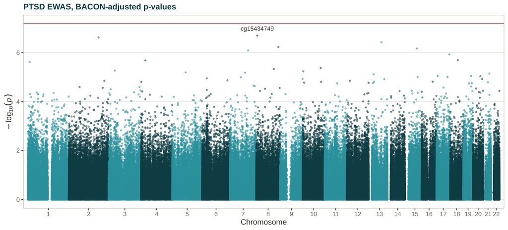

Manhattan plot of the EWAS, drawn on the BACON-adjusted p-values — the ones the chapter recommends you report. No CpG crosses the Bonferroni line (plum); the top-ranked CpG, `cg15434749`, is labelled. A near-empty Manhattan is the expected result for a subtle psychiatric phenotype in a small teaching subset (n=86); the full Grady Trauma Project cohort (n≈800) and meta-analysis across cohorts is what powers genome-wide discovery for PTSD (Katrinli et al. 2024).

```r
top1 <- pl %>% slice_min(bacon.p, n = 1, with_ties = FALSE)   # the top-ranked CpG, labelled

manhattan(pl, "bacon.p", "PTSD EWAS, BACON-adjusted p-values") +
  geom_text(data = top1, aes(x, -log10(bacon.p), label = probe),
            inherit.aes = FALSE, vjust = -1.2, size = 3.3, colour = "#3A362F")
```

A QQ plot summarises the same BACON-adjusted results across all CpGs at once. BACON’s own version is among the diagnostics above. Code for producing your own qq plots is provided here so you can make them for your own studies. Each CpG’s observed p-value is plotted against the p-value it would have under a null distribution.

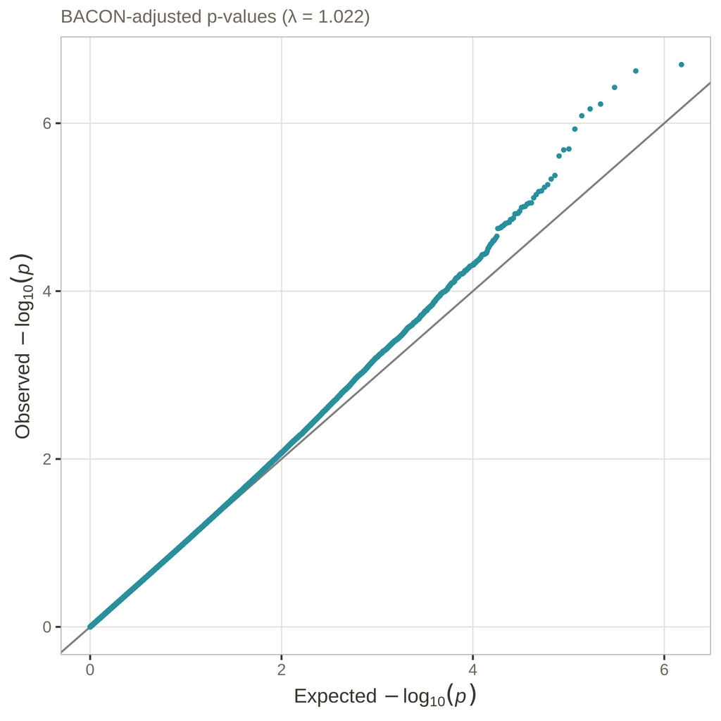

QQ plot of the BACON-adjusted EWAS p-values. Points on the diagonal are what a study with no associations produces; a curve lifting off the line across the whole range is inflation, while a departure confined to the far right is candidate signal. The genomic inflation factor λ is in the subtitle. The curve follows the diagonal through the bulk of the distribution and lies slightly above it in the upper tail; the most extreme CpG reaches −log₁₀ p = 6.70, below the Bonferroni threshold of 7.18.

```r
n <- nrow(tt)
qq <- data.frame(expected = -log10(ppoints(n)),
                 observed = -log10(sort(tt$bacon.p)))

ggplot(qq, aes(expected, observed)) +
  geom_abline(slope = 1, intercept = 0, colour = "#7F7F7F") +
  geom_point(size = 0.8, colour = "#2A8F9B") +
  labs(x = expression(Expected~-log[10](italic(p))),
       y = expression(Observed~-log[10](italic(p))),
       subtitle = sprintf("BACON-adjusted p-values (\u03bb = %.3f)", bs$lambda_bacon))
```

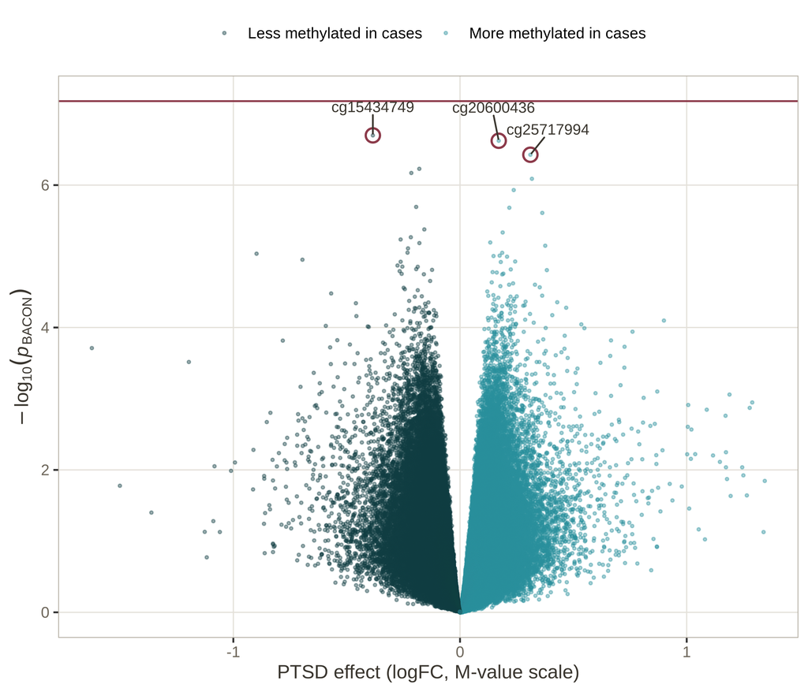

Volcano plot. The x-axis is the EWAS effect size itself — the `ptsdCase` coefficient from the limma fit (logFC), on the M-value scale, adjusted for every covariate in the design; the y-axis is the BACON-adjusted p-value. Colour marks the sign of that coefficient: dark teal for CpGs less methylated in cases, light teal for those more methylated. Note that this is the adjusted effect, so its sign can differ from a raw case-minus-control β difference for probes where the covariates carry part of the signal. The plum line is the Bonferroni threshold, which no CpG crosses. The three top-ranked CpGs are ringed and labelled: `cg15434749` (logFC −0.385, Δβ −0.026), `cg20600436` (logFC 0.171, Δβ 0.014) and `cg25717994` (logFC 0.310, Δβ 0.006). Even they move methylation only slightly, illustrating that EWAS effect sizes for complex phenotypes are typically small and require large samples to detect reliably.

```r
library(ggrepel)      # geom_text_repel(): keeps the three labels from overlapping

# x: the tested ptsdCase coefficient (logFC, M-value scale); y: BACON-adjusted p.
vd <- tt %>%
  select(probe, logFC, bacon.p) %>%
  mutate(direction = ifelse(logFC < 0, "Less methylated in cases",
                                       "More methylated in cases"))
top3 <- vd %>%                                       # the three top-ranked CpGs
  arrange(bacon.p) %>%
  slice_head(n = 3)

ggplot(vd, aes(logFC, -log10(bacon.p), colour = direction)) +
  geom_point(size = 0.6, alpha = 0.4) +
  geom_hline(yintercept = -log10(bonf), colour = "#8C3A4A") +          # plum
  geom_point(data = top3, shape = 21, fill = NA, colour = "#8C3A4A",
             size = 3.5, stroke = 1) +
  geom_text_repel(data = top3, aes(label = probe), colour = "#3A362F",
                  size = 3.3, nudge_y = 0.4, min.segment.length = 0,
                  segment.colour = "#3A362F", seed = 1) +
  scale_colour_manual(values = c(`Less methylated in cases` = "#0F3D43",
                                 `More methylated in cases` = "#2A8F9B"),
                      name = NULL) +
  labs(x = "PTSD effect (logFC, M-value scale)",
       y = expression(-log[10](italic(p)[BACON]))) +
  theme(legend.position = "top")
```

## 6. An alternative in common use: the M-value residual workflow

The design above puts **all** covariates — biological and technical — into one large regression. A common alternative, and the convention many groups (including this tutorial’s pipeline author) prefer, is a **two-stage residualization**:

1. **Regress the technical variation out first.** Fit each CpG’s M-value on only the technical/nuisance terms (surrogate variables, or recorded batch such as chip and position) and keep the **residuals** — the methylation signal with technical structure removed.
2. **Run the association on the residuals** with only the biological model:
   $$\text{resid}(\text{M})_{\text{CpG}} \sim \text{PTSD} + \text{sex} + \text{age} + \text{smoking proxy} + \text{cell composition} + \text{ancestry PCs}$$

```
Generic example, do not run
```

```r
# Schematic only -- placeholder names, not objects this chapter creates.
# Stage 1: residualize M-values on the technical terms (SVs here; or chip + position)
tech    <- model.matrix(~ SV)                      # nuisance-only design
M_resid <- residuals(lmFit(mvals, tech), mvals)    # limma residuals, probes x samples

# Stage 2: association model on the residuals, biological covariates only
bio <- model.matrix(~ exposure + sex + age + smoking + cell_proportions + ancestry_pcs, data = pheno)
fit <- eBayes(lmFit(M_resid, bio))
```

**Why do this?** The usual motivation is **degrees of freedom**. Our single-stage model spends 27 design columns *per probe*; at n = 86 that leaves 59 residual df. Moving the technical terms into a first stage — where they are estimated once — leaves the association model lean (`PTSD + sex + age + smoking proxy + 6 cell props + 3 ancestry PCs`) and returns df to the test that matters.

It is also common to regress out the blood cell proportions in addition to the technical variation prior to running the main model. There is no *wrong* choice in which or how many covariates you adjust for prior to the EWAS, just make sure to report what exactly was done in your methods.

**WarningThe caveat: residualization understates uncertainty**

Two-stage residualization treats the stage-1 fitted values as *known* when it runs stage 2, so it doesn’t propagate the uncertainty of estimating the technical terms. In practice, with many samples relative to nuisance terms, the difference from the single-stage model is small and the df savings are worth it — which is why it is widely used. But be aware it is an approximation to the joint model, not identical to it. Report which approach you used, and ideally confirm the top hits are stable under both.

## 7. When and why to stratify, then meta-analyze

The model so far adjusts for sex as a **covariate**: it lets men and women have different mean methylation, but forces the *PTSD effect* to be a single number shared across both. That assumption is often wrong for methylation.

### Why sex is a special case in methylation

Sex is one of the largest sources of variation in the methylome, and it is not just an X/Y-chromosome effect — autosomal CpGs show widespread sex differences in mean level, in variance, and in how they *respond* to exposures and phenotypes. When the effect of your exposure/trait/disease genuinely differs between men and women (a sex interaction), a sex-adjusted model estimates a blend of the two and can miss a real signal that is present in only one sex, or that points in opposite directions. Because sex-specific methylation effects are common, I strongly recommend performing sex-stratified analyses.

More generally, stratify when you have reason to believe the **effect itself** (not just the baseline) differs across a grouping variable: genetic ancestry, tissue or cell subtype, exposure dose, or age categories can all justify it. The cost is power — each stratum has fewer samples — so stratification trades a cleaner, assumption-light estimate within each group against reduced within-stratum sample size. However, the loss of power from sample size can be recovered with meta-analysis to re-join the strata results.

### Stratify → analyze → meta-analyze

The workflow is three steps:

1. **Split** the data by the stratifying variable (e.g. sex) and drop that variable from the covariate set within each stratum — it is now constant.
2. **Run the full EWAS separately** in each stratum: the same model, the same BACON adjustment, the same diagnostics, per stratum.
3. **Meta-analyze** the per-stratum results with an inverse-variance-weighted fixed-effect meta-analysis, which combines the two effect estimates weighting each by its precision (1/SE²). This recovers power from both strata while still allowing the underlying effects to differ — and it gives you a **heterogeneity test** (Cochran’s *Q*, *I²*) that formally asks whether the sexes differ at each CpG.

The standard tool for performing meta analysis in genomics is **METAL** (Willer et al. 2010) and can also be used for epigenomics. It reads each stratum’s results file, matches CpGs by ID, does the inverse-variance weighting and the heterogeneity test genome-wide, and writes a combined table. Chapter 07 runs the stratified EWAS and METAL as a managed workflow. METAL’s `SCHEME STDERR` *is* an inverse-variance-weighted fixed-effects meta-analysis, so the R code below and METAL produce exactly the same results.

Inverse-variance meta-analysis is short enough to show in full. Every line below is vectorized, so this is the whole genome-wide meta-analysis, not a one-CpG illustration:

```
Generic example, do not run
```

```r
# Schematic only -- the arithmetic, with the inputs named rather than built.
# resF and resM: each stratum's BACON-adjusted results, one row per CpG, with
# columns probe, effect and se. Align them on the CpGs tested in both strata;
# everything after this line is vectorized over all of them at once.
m   <- inner_join(resF, resM, by = "probe", suffix = c("F", "M"))
bF  <- m$effectF;  seF <- m$seF          # female effect and SE, one per CpG
bM  <- m$effectM;  seM <- m$seM          # male effect and SE

wF <- 1 / seF^2                       # inverse-variance weights
wM <- 1 / seM^2
beta_meta <- (wF*bF + wM*bM) / (wF + wM)      # combined effect
se_meta   <- sqrt(1 / (wF + wM))              # combined standard error
z_meta    <- beta_meta / se_meta
p_meta    <- 2 * pnorm(-abs(z_meta))

# heterogeneity: does the effect differ between the sexes?
Q     <- wF*(bF - beta_meta)^2 + wM*(bM - beta_meta)^2   # Cochran's Q, 1 df
p_het <- pchisq(Q, df = 1, lower.tail = FALSE)
I2    <- pmax(0, (Q - 1) / Q) * 100           # % of between-stratum variance

# direction string, the way METAL reports it: one sign per stratum
direction <- paste0(ifelse(bF > 0, "+", "-"), ifelse(bM > 0, "+", "-"))

meta <- data.frame(probe = m$probe, beta_meta, se_meta, p_meta, p_het, I2, direction)
meta <- arrange(meta, p_meta)
```

The direction and heterogeneity columns are interpretive rather than a quality filter. Concordance strengthens a combined estimate; discordance can point to a genuine stratum-specific effect (in this case discordance could indicate sex-specific effects), which is part of why you stratified. In a multi-cohort meta-analysis, where the strata are meant to be replicates, the discordance would indicate lower credibility.

Two things follow for how you read a meta-analysed table:

1. **Check the arms.** For every hit you plan to report, look up the per-stratum estimate, SE and p-value. If one arm is flat, you have a stratum-specific finding and you should describe it that way.
2. **Distrust `I²` at two strata.** With two studies and one heterogeneity degree of freedom, I² is extremely noisy. A CpG whose two estimates point in opposite directions can still report I² = 0 if one arm’s SE is large enough that the two are statistically compatible — low I² there means “not enough precision to tell them apart”, not “they agree”.

**TipWhy use METAL?**

METAL is the commonly used tool for meta-analysis of genome-wide association studies. METAL handles allele/strand alignment (irrelevant for methylation), reads many cohort files with inconsistent column names, tracks sample sizes per marker, and applies genomic-control correction on request. For a two-stratum methylation meta-analysis where you control both input files, the R above is easier to audit and keeps everything in one language. For a multi-cohort consortium meta-analysis, use METAL.

## Saving what we just computed

The fit and the BACON correction are the whole cost of this chapter. Three files carry them forward: the object chapter 08 reads, the calibration summary section 4 reports from, and a flat copy of the results table.

```r
# 1. The handoff object. `tt` is attached only now, after BACON, so that the
#    saved table already carries bacon.p / bacon.es / bacon.se / bacon.adj.P --
#    chapter 08 reads those columns straight out of this file and never reruns
#    the sampler.
ew$tt     <- tt
ew$lambda <- lambda
saveRDS(ew, "data/06_ewas.rds")

# 2. The four calibration numbers, on their own, for anything that needs them
#    without loading a 756,251-row table.
saveRDS(bs, "data/06_bacon_summary.rds")

# 3. A flat copy of the results table, one row per CpG. Gzipped CSV rather than
#    a tab-delimited file in the repository: 756,251 rows is far too large to
#    commit, so this one is deposited in the Zenodo record instead. The write
#    takes about a minute.
write.csv(tt, gzfile("data/06_ewas_bacon_toptable.csv.gz"), row.names = FALSE)
```

## 8. When you don’t have IDATs

Everything in this notebook operates on a **methylation matrix** and a phenotype table, so the non-IDAT path is identical once you have M-values:

- Convert a deposited β-matrix to M-values (`M = log2(beta/(1-beta))`; see normalization).
- Obtain covariates from the series metadata: sex and age from `pData`, cell composition via a **reference-based estimator that runs on β-matrices** (e.g. `EpiDISH`/`RPC`) when you can’t run `estimateCellCounts2` from IDATs (chapter 04 covers this), and surrogate variables from `sva` run on the matrix (chapter 05).
- Fit the identical `limma` model. The association step never touches raw intensities.

**Next:** Running the EWAS pipeline — scale this analysis with a reproducible Snakemake workflow that models methylation as the outcome, runs a **sex-stratified** EWAS, and meta-analyzes the strata with METAL. Then functional annotation of the results.

## References

Du, Pan, Xiao Zhang, Chiang-Ching Huang, et al. 2010. “Comparison of Beta-Value and m-Value Methods for Quantifying Methylation Levels by Microarray Analysis.” *BMC Bioinformatics* 11: 587. https://doi.org/10.1186/1471-2105-11-587.

Iterson, Maarten van, Erik W van Zwet, Bastiaan T Heijmans, and the BIOS Consortium. 2017. “Controlling Bias and Inflation in Epigenome- and Transcriptome-Wide Association Studies Using the Empirical Null Distribution.” *Genome Biology* 18 (1): 19. https://doi.org/10.1186/s13059-016-1131-9.

Katrinli, Seyma et al. 2024. “Epigenome-Wide Association Studies Identify Novel DNA Methylation Sites Associated with PTSD: A Meta-Analysis of 23 Military and Civilian Cohorts.” *Genome Medicine* 16: 147. https://doi.org/10.1186/s13073-024-01417-1.

Ritchie, Matthew E, Belinda Phipson, Di Wu, et al. 2015. “Limma Powers Differential Expression Analyses for RNA-Sequencing and Microarray Studies.” *Nucleic Acids Research* 43 (7): e47. https://doi.org/10.1093/nar/gkv007.

Willer, Cristen J, Yun Li, and Gonçalo R Abecasis. 2010. “METAL: Fast and Efficient Meta-Analysis of Genomewide Association Scans.” *Bioinformatics* 26 (17): 2190–91. https://doi.org/10.1093/bioinformatics/btq340.